# Preparing State, County, Fips, and Center Data

Ilyas Ustun

2017-07-12

This presentation can also be seen at [datacademy](https://www.datacademy.co)

# Preparing State, County, Fips, and Center Data of States and Counties

ggplot2 package is known for its beautiful plots in R, such as histograms, boxplots, scatter plots etc. However, one can do geospatial mapping as well with this package. Here we’ll first build the data step by step using *map_data* and *fips* data, and then use the *geom_polygon* that will enable us to perform geospatial mapping.

The ggplot2::map_data function has the polygon data of longitudes, and latitudes imported from the maps package.

## State and County Polygon Data

```r
# Import libraries
library(tidyverse)
library(data.table)
library(DT)
library(knitr)
library(stringr)
```

Let’s first check whether there are some counties which have special endings such as: *city, county, parish*.

```r
x = map_data('county') %>% as.data.table()
setnames(x, c('region', 'subregion'), c('state','county'))

d_city = x[county %>% str_detect('city'), .(group = unique(group)), keyby = .(state, county)]
d_city
```

```
##       state         county group
## 1: maryland baltimore city  1183
## 2: missouri  st louis city  1545
## 3:   nevada    carson city  1731
## 4: virginia   charles city  2809
## 5: virginia     james city  2837
```

```r
x[county %>% str_detect('county'), .N]
```

```
## [1] 0
```

```r
x[county %>% str_detect('parish'), .N]
```

```
## [1] 0
```

```r
v_without_city = str_replace(d_city$county, 'city', '') %>%
    str_trim(side = 'right')
d_city[, without_city := v_without_city]


v = list()
for (i in seq(nrow(d_city)) ) {
    counties = x[state == d_city[i = i, state], unique(county)]
    present = str_detect(string = counties, pattern = d_city$without_city[i])
    v[[i]] = data.table(state = d_city$state[i], county = counties[present])
}
rbindlist(v) %>% datatable()
```

|  | state | county |
| --- | --- | --- |
| 1 | maryland | baltimore |
| 2 | maryland | baltimore city |
| 3 | missouri | st louis |
| 4 | missouri | st louis city |
| 5 | nevada | carson city |
| 6 | virginia | charles city |
| 7 | virginia | james city |

Two counties have a plain name, and same name ending with *“city”*, namely St Louis City, and Baltimore City. We need to keep this in mind when working with fips data, and other datasets in the future. Since, the *“city”* ending is unique and is separate area from the corresponding plain name, they will not be removed from their names.

```r
fun_load_polygon = function(map_type) {
    x = map_data(map = map_type) %>% as.data.table()
    setnames(x, c('region', 'subregion'), c('state', 'county'))
    x2 = x[, .(state, county)] %>%
        map_df(.f = str_to_lower) %>%
        map_df(.f = str_replace_all, pattern = '[[:punct:]]', replacement = '') %>%
        map_df(.f = str_replace_all, pattern = '[[:space:]]', replacement = '') %>%
        as.data.table()

    if (map_type == 'county') {
        x2[state == 'districtofcolumbia' & county == 'washington',
           county := 'districtofcolumbia']
        x2[state == 'montana' & county == 'yellowstonenational',
           county := 'yellowstone']
    }

    x$state = x2$state
    x$county = x2$county
    return(x)
}

polygon_state = fun_load_polygon('state')
polygon_county = fun_load_polygon('county')
polygon_state[1:1000, ] %>% datatable(caption = 'State Polygon', rownames = F)
```

| long | lat | group | order | state | county |
| --- | --- | --- | --- | --- | --- |
| -87.4620056152344 | 30.3896808624268 | 1 | 1 | alabama |  |
| -87.4849319458008 | 30.3724918365479 | 1 | 2 | alabama |  |
| -87.525032043457 | 30.3724918365479 | 1 | 3 | alabama |  |
| -87.53076171875 | 30.3323860168457 | 1 | 4 | alabama |  |
| -87.5708694458008 | 30.3266544342041 | 1 | 5 | alabama |  |
| -87.5880584716797 | 30.3266544342041 | 1 | 6 | alabama |  |
| -87.5937881469727 | 30.3094673156738 | 1 | 7 | alabama |  |
| -87.5937881469727 | 30.286548614502 | 1 | 8 | alabama |  |
| -87.6740036010742 | 30.275089263916 | 1 | 9 | alabama |  |
| -87.8115158081055 | 30.2579021453857 | 1 | 10 | alabama |  |

[output cut: 990 more lines]

```r
polygon_county[1:1000, ] %>% datatable(caption = 'County Polygon', rownames =F)
```

| long | lat | group | order | state | county |
| --- | --- | --- | --- | --- | --- |
| -86.5051651000977 | 32.3491973876953 | 1 | 1 | alabama | autauga |
| -86.533821105957 | 32.3549270629883 | 1 | 2 | alabama | autauga |
| -86.5452728271484 | 32.3663864135742 | 1 | 3 | alabama | autauga |
| -86.5567321777344 | 32.3778457641602 | 1 | 4 | alabama | autauga |
| -86.5796585083008 | 32.3835716247559 | 1 | 5 | alabama | autauga |
| -86.5911102294922 | 32.3778457641602 | 1 | 6 | alabama | autauga |
| -86.6140289306641 | 32.3893051147461 | 1 | 7 | alabama | autauga |
| -86.619758605957 | 32.4064903259277 | 1 | 8 | alabama | autauga |
| -86.62548828125 | 32.4179534912109 | 1 | 9 | alabama | autauga |
| -86.6369476318359 | 32.4179534912109 | 1 | 10 | alabama | autauga |

[output cut: 990 more lines]

```r
# polygon_county[state == 'montana' & county == 'yellowstone']
# polygon_county[state == 'montana' & county == 'park']
```

The punctutations and spacings have been removed, and the names have been converted to all lower case. The aim of this is to make the datasets as universal as possible, so that they can be merged with other datasets easily.

One interesting fact that I found out is that county Chesapeake in Virginia is not present in the county polygon data, but is present in state polygon data. However, Chesapeake in state polygon data is named wrong, and here together with Chincoteague represents the northern peninsula of Virginia that stretches to Maryland. It is actually the counties of Accomack, and Northampton. This peninsula is shown in the map below. So, it should not be confused with the real Chesapeake.

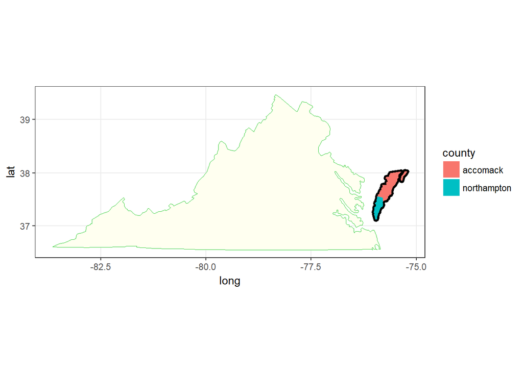

```r
ggplot(data = polygon_state[state == 'virginia'], mapping = aes(x = long, y = lat, group = group)) +
    geom_polygon(fill = 'ivory1', color = "limegreen", size = 0.1) +
    geom_polygon(data = polygon_state[county %in% c('chesapeake', 'chincoteague')], col = 'black', size = 2) +
    geom_polygon(data = polygon_county[state == 'virginia' & county %in% c('accomack', 'northampton')], aes(fill = county)) +
    coord_map('mercator') +
    theme_bw()
```

The county name “Washington” within the state of “District of Columbia” has been renamed to “District of Columbia”, and the county name “Yellowstone National” has been renamed to “Yellowstone”, as these names are more common in databases. Depending on your data that contains the values to be analyzed, one can play with the names of the counties to match them. Even better, using a common unique identifier can help in the process and decrease the chances of making an error. Fips is such a unique identifier used in the geographical mapping of state and county data. States and counties each have their own unique fips code.

Next step will involve the process of preparing the fips data. Maps package in R contains the county fips dataset.

## Fips Data

```r
library(maps)
data("county.fips")
head(county.fips) %>% kable()
```

| fips | polyname |
| --- | --- |
| 1001 | alabama,autauga |
| 1003 | alabama,baldwin |
| 1005 | alabama,barbour |
| 1007 | alabama,bibb |
| 1009 | alabama,blount |
| 1011 | alabama,bullock |

```r
county.fips = str_split(string = county.fips$polyname, pattern = ',', simplify = T) %>%
    as.data.frame() %>%
    map_df(.f = str_to_lower) %>%
    map_df(.f = str_replace_all, pattern = '[[:punct:]]', replacement = '') %>%
    map_df(.f = str_replace_all, pattern = '[[:space:]]', replacement = '') %>%
    cbind(county.fips$fips) %>%
    as.data.table() %>%
    setnames(c('state', 'county', 'fips'))

county.fips %>% datatable()
```

|  | state | county | fips |
| --- | --- | --- | --- |
| 1 | alabama | autauga | 1001 |
| 2 | alabama | baldwin | 1003 |
| 3 | alabama | barbour | 1005 |
| 4 | alabama | bibb | 1007 |
| 5 | alabama | blount | 1009 |
| 6 | alabama | bullock | 1011 |
| 7 | alabama | butler | 1013 |
| 8 | alabama | calhoun | 1015 |
| 9 | alabama | chambers | 1017 |
| 10 | alabama | cherokee | 1019 |

[output cut: 3075 more lines]

Let’s check whether the fips data has some common suffixes at the end of counties:

```r
# Suspecting for some counties having suffixes such as:
x = county.fips
d_city = x[county %>% str_detect('city'), .SD]
d_city
```

```
##       state        county  fips
## 1: maryland baltimorecity 24510
## 2: missouri   stlouiscity 29510
## 3:   nevada    carsoncity 32510
## 4: virginia   charlescity 51036
## 5: virginia     jamescity 51095
```

```r
d_county = x[county %>% str_detect('county'), .SD]
d_county
```

```
## Empty data.table (0 rows) of 3 cols: state,county,fips
```

```r
d_parish = x[county %>% str_detect('parish'), .SD]
d_parish
```

```
## Empty data.table (0 rows) of 3 cols: state,county,fips
```

```r
d_main = x[county %>% str_detect('main'), .SD]
d_main
```

```
##            state        county  fips
## 1:       florida  okaloosamain 12091
## 2: northcarolina currituckmain 37053
## 3:         texas galvestonmain 48167
## 4:      virginia  accomackmain 51001
## 5:    washington    piercemain 53053
```

```r
fun_counties_with_extra_names = function(d = county.fips, d_extra, extra = 'main') {
    v_without = str_sub(d_extra$county, 1, str_length(d_extra$county) - str_length(extra))
    counties_extra = list_along(v_without)
    for (i in seq_along(v_without)) {
        counties_extra[[i]] = d[county %>% str_detect(v_without[i]) &
                                    state == d_extra[i, state], .SD]
    }
    return(data.table::rbindlist(counties_extra))
}
```

Counties in the fips set do not end with either *county* or *parish*.

Counties that have *city* as their ending:

```r
extra = 'city'
county_extra = fun_counties_with_extra_names(d = county.fips,
                                             d_extra = d_city, extra)
county_extra %>% datatable()
```

|  | state | county | fips |
| --- | --- | --- | --- |
| 1 | maryland | baltimore | 24005 |
| 2 | maryland | baltimorecity | 24510 |
| 3 | missouri | stlouis | 29189 |
| 4 | missouri | stlouiscity | 29510 |
| 5 | nevada | carsoncity | 32510 |
| 6 | virginia | charlescity | 51036 |
| 7 | virginia | jamescity | 51095 |

The counties that have a plain name, and same name ending with *city* are unique, and so do not constitute a problem.

Counties that have *main* as their ending:

```r
extra = 'main'
county_extra = fun_counties_with_extra_names(d = county.fips,
                                             d_extra = d_main, extra)
county_extra %>% datatable()
```

|  | state | county | fips |
| --- | --- | --- | --- |
| 1 | florida | okaloosamain | 12091 |
| 2 | florida | okaloosaspit | 12091 |
| 3 | northcarolina | currituckknotts | 37053 |
| 4 | northcarolina | currituckmain | 37053 |
| 5 | northcarolina | currituckspit | 37053 |
| 6 | texas | galvestonmain | 48167 |
| 7 | texas | galvestonspit | 48167 |
| 8 | virginia | accomackmain | 51001 |
| 9 | virginia | accomackchincoteague | 51001 |
| 10 | washington | piercemain | 53053 |

[output cut: 1 more lines]

The counties that have a plain name with various suffixes, and one ending with *main* are identical areas, indicated by the same fips code, and so do constitute a problem. We will need to get rid of these.

Let’s first get rid of the extra entries for counties with *main*.

```r
fun_clean_counties_with_extra_names = function(d, d_extra, extra = 'main') {
    # get rid of any county that has "extra" and other suffixes
    d = d[!fips %in% county_extra$fips]
    # get rid of "extra" part of counties
    d_extra$county = str_sub(d_extra$county, 1, str_length(d_extra$county) - str_length(extra))
    # append it to county.fips data
    return( rbind(d, d_extra) )
}

extra = 'main'
county.fips = fun_clean_counties_with_extra_names(d = county.fips,
                                                  d_extra = d_main, extra)
```

Now, let’s check whether there are any other duplicates.

```r
dup = county.fips[duplicated(x = county.fips$fips), fips ]
county.fips[fips %in% dup, ]
```

```
##         state               county  fips
## 1:  louisiana        stmartinnorth 22099
## 2:  louisiana        stmartinsouth 22099
## 3:    montana                 park 30067
## 4:    montana  yellowstonenational 30067
## 5: washington   sanjuanlopezisland 53055
## 6: washington   sanjuanorcasisland 53055
## 7: washington sanjuansanjuanisland 53055
```

```r
county.fips[county %in% c('yellowstone', 'park') & state == 'montana', ] %>% kable()
```

| state | county | fips |
| --- | --- | --- |
| montana | park | 30067 |
| montana | yellowstone | 30111 |

Indeed there are other duplicate entries. Let’s clean these remaining duplicates. It is found out *Yellowstone* in Montana has fips code 30111. From other datasets it is also verified that county *Park* in Montana has fips code 30067. Thus, for the repeated values in Montana, the one to be kept is *Park*.

```r
county.fips[fips == 22099, county := 'stmartin']
county.fips[fips == 30067, county := 'park']
county.fips[fips == 53055, county := 'sanjuan']
county.fips = county.fips[!duplicated(county.fips)]

county.fips[duplicated(county.fips$fips)]
```

```
## Empty data.table (0 rows) of 3 cols: state,county,fips
```

```r
county.fips[state == 'districtofcolumbia', county := 'districtofcolumbia']
```

Finally the fips dataset is clean and ready to be integrated into the polygon data.

Now, I will join the county polygon data with the fips code and save for later use. Since the *polygon_county* data’s counties match one to one with the ones at *county.fips*, we can join these to reach the desired dataset.

```r
polygon_county[, .(county = unique(county)), by = state][, county] %>%
    setdiff( county.fips[, county])
```

```
## character(0)
```

```r
polygon_county = left_join(polygon_county, county.fips,
                           by = c('state', 'county')) %>% as.data.table()
polygon_county[is.na(fips)]
```

```
## Empty data.table (0 rows) of 7 cols: long,lat,group,order,state,county...
```

```r
polygon_county[1:1000] %>% datatable()
```

|  | long | lat | group | order | state | county | fips |
| --- | --- | --- | --- | --- | --- | --- | --- |
| 1 | -86.5051651000977 | 32.3491973876953 | 1 | 1 | alabama | autauga | 1001 |
| 2 | -86.533821105957 | 32.3549270629883 | 1 | 2 | alabama | autauga | 1001 |
| 3 | -86.5452728271484 | 32.3663864135742 | 1 | 3 | alabama | autauga | 1001 |
| 4 | -86.5567321777344 | 32.3778457641602 | 1 | 4 | alabama | autauga | 1001 |
| 5 | -86.5796585083008 | 32.3835716247559 | 1 | 5 | alabama | autauga | 1001 |
| 6 | -86.5911102294922 | 32.3778457641602 | 1 | 6 | alabama | autauga | 1001 |
| 7 | -86.6140289306641 | 32.3893051147461 | 1 | 7 | alabama | autauga | 1001 |
| 8 | -86.619758605957 | 32.4064903259277 | 1 | 8 | alabama | autauga | 1001 |
| 9 | -86.62548828125 | 32.4179534912109 | 1 | 9 | alabama | autauga | 1001 |
| 10 | -86.6369476318359 | 32.4179534912109 | 1 | 10 | alabama | autauga | 1001 |

[output cut: 990 more lines]

Good. We have cleaned the fips data and joined with the cleaned polygon data.

## Center Data

The final step involves computing the **center** latitude and longitude of states and counties. This sort of data can be useful when we want to plot something in the center of states or counties.

```r
# Input data is the polygon data
# d has long and lat variables for the state-county combinations (or fips)
fun_get_centers = function(d) {

    # d[, .(atan2( sum(cos(long)), sum(cos(lat)) ) )]
    d = copy(d)
    d[, `:=`(long_rad = long*pi/180, lat_rad = lat*pi/180)]

    xyz = d[, .( x = mean( cos(lat_rad) * cos(long_rad) ),
                 y = mean( cos(lat_rad) * sin(long_rad) ),
                 z = mean( sin(lat_rad) ) ), by = .(state, county, group)]

    # central_long = atan2(y,x)
    # central_square_root = sqrt(x^2 + y^2)
    # central_lat = atan2(z, central_square_root)

    xyz = xyz[, {
                    cent_long = atan2(y,x)
                    cent_sqrt = sqrt(x^2 + y^2)
                    cent_lat  = atan2(z, cent_sqrt)

                    cent_lat = cent_lat * 180/pi
                    cent_long = cent_long * 180/pi

                    list(long = cent_long,
                         lat = cent_lat)


              }, by = .(state, county, group)]

    return(xyz)

}

center_county = fun_get_centers(polygon_county)
center_state = fun_get_centers(polygon_state)

center_county = left_join(center_county, county.fips) %>% as.data.table()
dup = center_county[duplicated(center_county$fips), fips]
center_county[fips %in% dup,] %>% kable()
```

| state | county | group | long | lat | fips |
| --- | --- | --- | --- | --- | --- |
| florida | okaloosa | 335 | -86.56789 | 30.58918 | 12091 |
| florida | okaloosa | 336 | -86.45881 | 30.43240 | 12091 |
| louisiana | stmartin | 1128 | -91.72565 | 30.23448 | 22099 |
| louisiana | stmartin | 1129 | -91.28414 | 29.84270 | 22099 |
| montana | yellowstone | 1620 | -108.18860 | 46.02341 | 30111 |
| montana | yellowstone | 1621 | -110.75128 | 44.98961 | 30111 |
| northcarolina | currituck | 1883 | -75.95462 | 36.52606 | 37053 |
| northcarolina | currituck | 1884 | -75.96341 | 36.35219 | 37053 |
| northcarolina | currituck | 1885 | -75.70764 | 36.11839 | 37053 |
| texas | galveston | 2575 | -95.04942 | 29.46282 | 48167 |
| texas | galveston | 2576 | -94.56639 | 29.52865 | 48167 |
| virginia | accomack | 2790 | -75.31457 | 37.94509 | 51001 |
| virginia | accomack | 2791 | -75.69053 | 37.72515 | 51001 |
| washington | pierce | 2917 | -122.05552 | 47.02515 | 53053 |
| washington | pierce | 2918 | -122.66869 | 47.31016 | 53053 |
| washington | sanjuan | 2919 | -122.82764 | 48.45774 | 53055 |
| washington | sanjuan | 2920 | -122.83491 | 48.64715 | 53055 |
| washington | sanjuan | 2921 | -123.02817 | 48.52786 | 53055 |

```r
center_county[is.na(fips)]
```

```
## Empty data.table (0 rows) of 6 cols: state,county,group,long,lat,fips
```

```r
# fwrite(polygon_county, str_c(files_dir, 'polygon_county.csv'))
# fwrite(polygon_state, str_c(files_dir, 'polygon_state.csv'))
# fwrite(center_county, str_c(files_dir, 'center_county.csv'))
# fwrite(center_state, str_c(files_dir, 'center_state.csv'))
```

It should be noted that 8 counties are divided by waterways, and thus have different groupings of polygon values. They are not duplicate records. This effect can also be seen in the *center_state* data. There is also no missing fips code in the polygon set. So the *center_county* and *center_state* datasets are clean and ready for analysis.